# 03-Cleaned Burning Glass Data Profiling

## 4. job of veterans

```r
bg_vet_job <- bg_full_cleaned %>%
  filter(veteran == "veteran")%>%
  select(id, onet, jobposition, noofjobs,sector, startdate, enddate, start_month, end_month, start_day, end_day, onet_title, onet_job_zone, job_duration_day, tenure)%>%
  filter(!is.na(onet) & !is.na(jobposition) &  !is.na(startdate) & !is.na(enddate))


bg_vet_job%>%
  data_profiling()%>%
  gt()%>%
  tab_header(
    title ="data profiling on cleaned job variables among veterans"
  )
```

data profiling on cleaned job variables among veterans

| var | variable_type | num_unique | num_missing | perc_missing |
| --- | --- | --- | --- | --- |
| id | integer | 7704 | 0 | 0.00 |
| onet | character | 643 | 0 | 0.00 |
| jobposition | integer | 19 | 0 | 0.00 |
| noofjobs | integer | 19 | 0 | 0.00 |
| sector | character | 21 | 16721 | 51.69 |
| startdate | Date | 966 | 0 | 0.00 |
| enddate | Date | 960 | 0 | 0.00 |
| start_month | numeric | 12 | 0 | 0.00 |
| end_month | numeric | 12 | 0 | 0.00 |
| start_day | integer | 31 | 0 | 0.00 |
| end_day | integer | 31 | 0 | 0.00 |
| onet_title | character | 643 | 0 | 0.00 |
| onet_job_zone | numeric | 5 | 0 | 0.00 |
| job_duration_day | numeric | 2100 | 0 | 0.00 |
| tenure | character | 2 | 0 | 0.00 |

```
## 4 columns ignored with more than 50 categories.
## onet: 643 categories
## startdate: 966 categories
## enddate: 960 categories
## onet_title: 643 categories
```

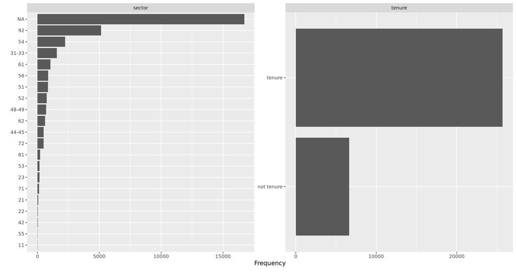

```r
plot_bar(bg_vet_job)
```

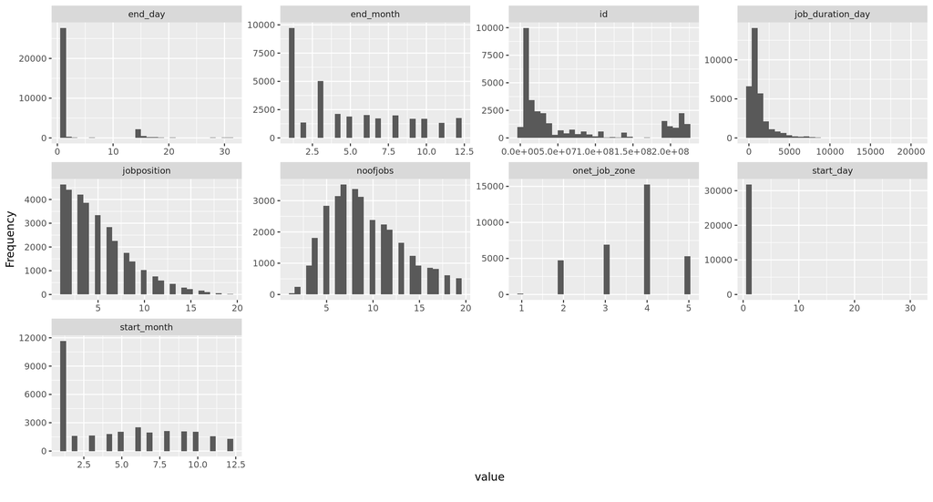

```r
plot_histogram(bg_vet_job)
```

# Demographic

## Veteran v.s. Non-veteran's Gender

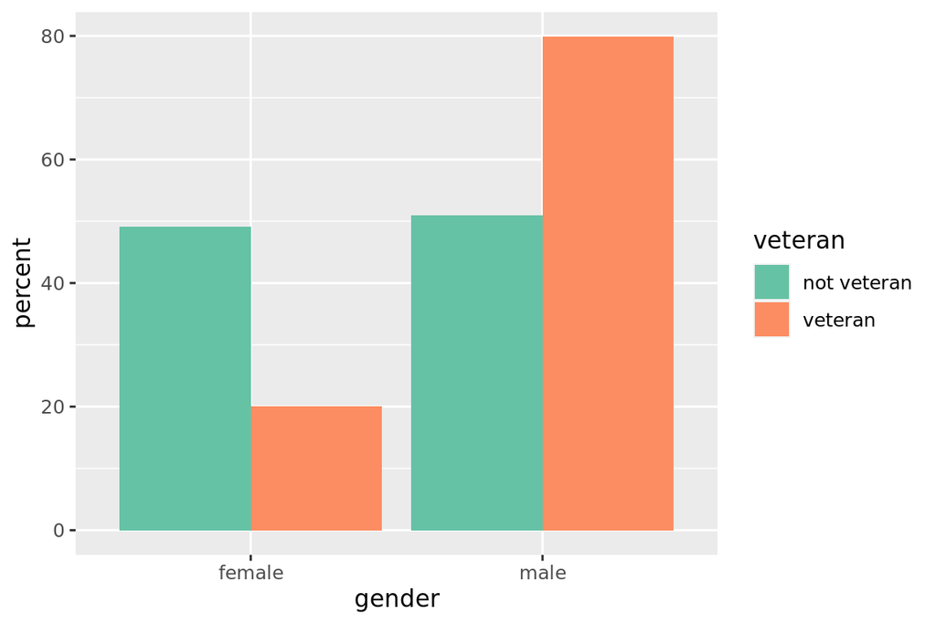

```r
vet_sex <- table(bg_demographic$veteran, bg_demographic$gender)%>%
  as.data.frame()%>%
  rename("veteran" = "Var1", "gender" = "Var2")%>%
  group_by(veteran)%>%
  summarize(gender=gender,percent = Freq / sum(Freq) * 100)

ggplot(vet_sex, aes(x = gender, y = percent, fill=veteran))+
  geom_bar( stat = "identity", position = "dodge")+
  scale_fill_brewer(palette = "Set2")
```

# Career

## Veteran v.s. Non-veteran's Degree Level

```r
bg_vet_edu<- bg_demographic%>%
  select(id, veteran, degree_highest)

vet_edu <- table(bg_vet_edu$veteran, bg_vet_edu$degree_highest)%>%
  as.data.frame()%>%
  rename("veteran" = "Var1", "education" = "Var2")%>%
  group_by(veteran)%>%
  summarize(education=education,percent = Freq / sum(Freq) * 100)%>%
  filter(!is.na(education))

unique(vet_edu$education)
```

```
## [1] associate   bachelor    certificate doctor      highschool  master
## [7] others      somehs
## 8 Levels: associate bachelor certificate doctor highschool master ... somehs
```

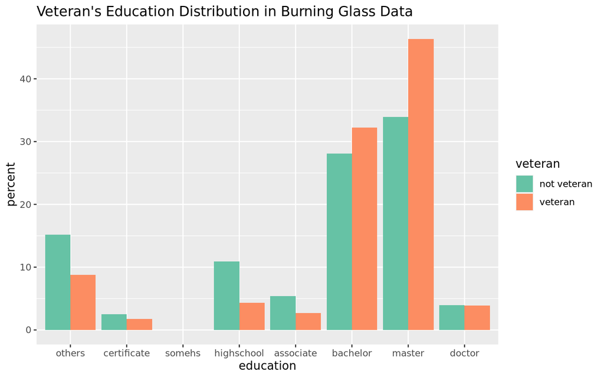

```r
vet_edu$education <- factor(vet_edu$education , levels = c("others","certificate","somehs", "highschool", "associate", "bachelor",  "master","doctor"))

ggplot(vet_edu, aes(x = education, y = percent, fill = veteran))+
  geom_bar(stat = "identity",position = 'dodge')+
  scale_fill_brewer(palette = "Set2")+
  labs(title = "Veteran's Education Distribution in Burning Glass Data")
```

## Veteran v.s. Non-veteran's Certificates (exclude)

```r
# cert_vet <- bg_full%>%
#   filter(!is.na(cert_name))%>%
#   group_by(veteran, cert_name)%>%
#   summarize(ttl_cert = n())%>%
#   group_by(veteran)%>%
#   top_n(10, ttl_cert)%>%
#   group_by(veteran)%>%
#   summarize(cert_name=cert_name, percent = ttl_cert / sum(ttl_cert) * 100)
#
# ggplot(cert_vet, aes(x = cert_name, y = percent, fill = veteran))+
#   geom_bar(stat = "identity",position = 'dodge')+
#   scale_fill_brewer(palette = "Set2")+
#   coord_flip()+
#   labs(title = "Top Certificates for Veterans v.s. Non-Veterans", x = "certificate")
```

-jobposition: smaller more recent job updates -onet job zone: 1-5, larger requires more skills and preparation

### More Analysis

#### Temporary jobs

20.53% (N=6640) of the jobs are not tenured.

```r
summary(bg_vet_job$job_duration_day)
```

```
##    Min. 1st Qu.  Median    Mean 3rd Qu.    Max.
##       5     365     730    1198    1400   20624
```

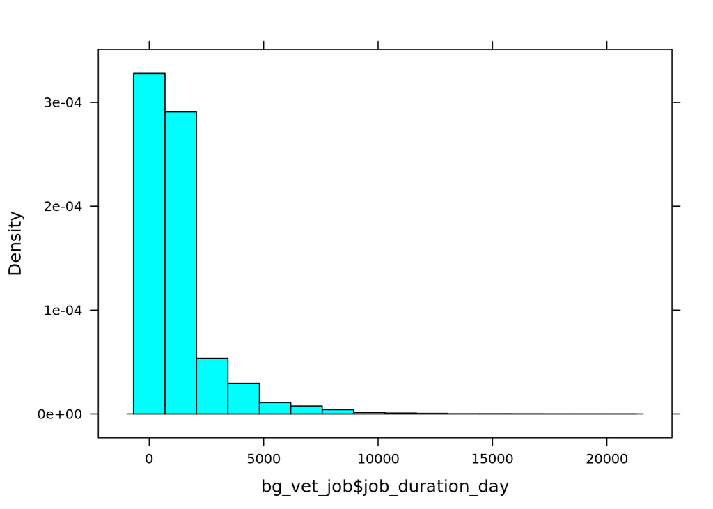

```r
histogram(bg_vet_job$job_duration_day)
```

```r
nrow = nrow(bg_vet_job)

bg_vet_job%>%
  group_by(tenure)%>%
  summarize(N=n(), perc = N/ nrow *100)
```

```
## # A tibble: 2 x 3
##   tenure         N  perc
##   <chr>      <int> <dbl>
## 1 not tenure  6640  20.5
## 2 tenure     25708  79.5
```

```r
n_tenure = 25708
n_not_tenure = 6640

bg_vet_job%>%
  group_by(tenure, onet_job_zone)%>%
  summarize(N=n())%>%
  mutate(perc = if_else(tenure == "tenure", 100*N/n_tenure, 100*N/n_not_tenure))
```

```
## # A tibble: 10 x 4
## # Groups:   tenure [2]
##    tenure     onet_job_zone     N   perc
##    <chr>              <dbl> <int>  <dbl>
##  1 not tenure             1    53  0.798
##  2 not tenure             2  1275 19.2
##  3 not tenure             3  1375 20.7
##  4 not tenure             4  2962 44.6
##  5 not tenure             5   975 14.7
##  6 tenure                 1    98  0.381
##  7 tenure                 2  3449 13.4
##  8 tenure                 3  5515 21.5
##  9 tenure                 4 12300 47.8
## 10 tenure                 5  4346 16.9
```

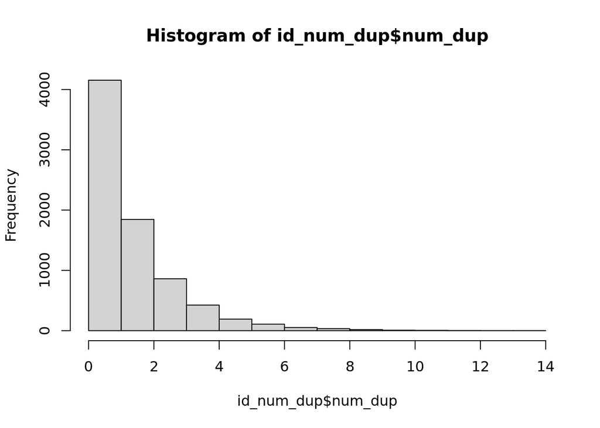

```r
#Changing jobs but in same occupation as a change or not?
bg_vet_job_transition <- bg_vet_job%>%
  select(id, onet, jobposition, onet_job_zone, onet_title, startdate, enddate)

#identify how many people have had a job change but in the same occupation
id <- unique(bg_vet_job_transition$id)
num_dup <- c()
for (i in 1: length(id)){
  message("check duplicates for individual #", i)
  pers <- id[i]
  bg_i <- bg_vet_job_transition%>%
    filter(id == pers)
  onet_i <- as.vector(bg_i$onet)
  if (sum(duplicated(onet_i)) == 0){
    num_dup[i] <- 0
  }else{
     num_dup[i] <- sum(duplicated(onet_i)) + 1 #sum of onet codes that are
  }
}

# cook book
# a <- c("apple", "banana", "cranberry")
# duplicated(a)
#
# b <- c("apple", "apple", "apple")
# duplicated(b)


id_num_dup <- as.data.table(cbind(id, num_dup))

hist(id_num_dup$num_dup)
```

```r
summary(id_num_dup$num_dup)
```

```
##    Min. 1st Qu.  Median    Mean 3rd Qu.    Max.
##    0.00    0.00    0.00    1.37    2.00   14.00
```

```r
table(id_num_dup$num_dup > 0)
```

```
##
## FALSE  TRUE
##  4154  3550
```

```r
table(id_num_dup$num_dup > 2)
```

```
##
## FALSE  TRUE
##  5999  1705
```

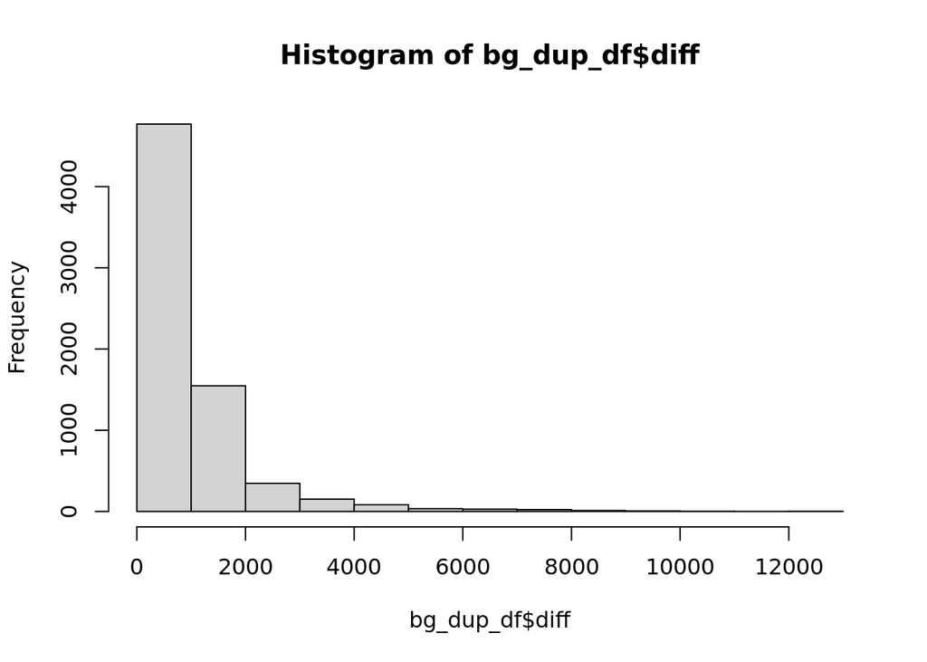

```r
# among those people who have duplicates
# identify how many of them had their later job(s) lasted for longer than one year
id_dup <- id_num_dup%>%
  filter(num_dup > 0)
id_dup <- as.vector(id_dup$id)

bg_dup_df<- c()
for (i in 1:length(id_dup)){
  message("check the time span of the duplicates for individual #", i)
  pers <- id_dup[i]
  bg_i <- bg_vet_job_transition%>%
    filter(id == pers)
  onet_i <- as.vector(bg_i$onet)
  dup_vec <-  duplicated(onet_i)
  bg_i <- as.data.frame(cbind(bg_i,dup_vec))
  bg_i <- bg_i%>%
    filter(dup_vec == T)%>%
    mutate(diff = as.numeric(enddate - startdate))
  bg_dup_df <- rbind(bg_dup_df, bg_i)
}



hist(bg_dup_df$diff)
```

```r
summary(bg_dup_df$diff)
```

```
##    Min. 1st Qu.  Median    Mean 3rd Qu.    Max.
##     5.0   365.0   700.0   955.3  1096.0 12372.0
```

```r
sd(bg_dup_df$diff)
```

```
## [1] 1107.515
```

```r
table(bg_dup_df$diff > 365)
```

```
##
## FALSE  TRUE
##  2209  4794
```

```r
table(id_num_dup$num_dup > 2)
```

```
##
## FALSE  TRUE
##  5999  1705
```